# Diversity Estimation Lab

## `breakaway` and `DivNet`

We’re going to learn about using `breakaway` and `DivNet` for diversity estimation and comparison!

Let’s begin by loading in all the packages we’ll need for this tutorial.

```r
library(breakaway)
library(DivNet)
library(phyloseq)
library(tidyverse)
library(ggplot2)
```

Let’s make sure that `breakaway` and `DivNet` are loaded properly

```r
data(apples)
head(apples)
```

```
##   index frequency
## 1     1       277
## 2     2       159
## 3     3       128
## 4     4        59
## 5     5        42
## 6     6        51
```

We are going to use data distributed from `phyloseq` called GlobalPatterns

```r
data("GlobalPatterns")
GlobalPatterns
```

```
## phyloseq-class experiment-level object
## otu_table()   OTU Table:         [ 19216 taxa and 26 samples ]
## sample_data() Sample Data:       [ 26 samples by 7 sample variables ]
## tax_table()   Taxonomy Table:    [ 19216 taxa by 7 taxonomic ranks ]
## phy_tree()    Phylogenetic Tree: [ 19216 tips and 19215 internal nodes ]
```

Here we see that GlobalPatterns is a `phyloseq` object containing an otu table, taxonomy table, sample data, and a phylogenetic tree.

Let’s take a look at the sample data for GlobalPatterns to see some more information about the data we’ll be using.

```r
GlobalPatterns %>% sample_data
```

```
##          X.SampleID  Primer Final_Barcode Barcode_truncated_plus_T
## CL3             CL3 ILBC_01        AACGCA                   TGCGTT
## CC1             CC1 ILBC_02        AACTCG                   CGAGTT
## SV1             SV1 ILBC_03        AACTGT                   ACAGTT
## M31Fcsw     M31Fcsw ILBC_04        AAGAGA                   TCTCTT
## M11Fcsw     M11Fcsw ILBC_05        AAGCTG                   CAGCTT
## M31Plmr     M31Plmr ILBC_07        AATCGT                   ACGATT
## M11Plmr     M11Plmr ILBC_08        ACACAC                   GTGTGT
## F21Plmr     F21Plmr ILBC_09        ACACAT                   ATGTGT
## M31Tong     M31Tong ILBC_10        ACACGA                   TCGTGT
## M11Tong     M11Tong ILBC_11        ACACGG                   CCGTGT
## LMEpi24M   LMEpi24M ILBC_13        ACACTG                   CAGTGT
## SLEpi20M   SLEpi20M ILBC_15        ACAGAG                   CTCTGT
## AQC1cm       AQC1cm ILBC_16        ACAGCA                   TGCTGT
## AQC4cm       AQC4cm ILBC_17        ACAGCT                   AGCTGT
## AQC7cm       AQC7cm ILBC_18        ACAGTG                   CACTGT
## NP2             NP2 ILBC_19        ACAGTT                   AACTGT
## NP3             NP3 ILBC_20        ACATCA                   TGATGT
## NP5             NP5 ILBC_21        ACATGA                   TCATGT
## TRRsed1     TRRsed1 ILBC_22        ACATGT                   ACATGT
## TRRsed2     TRRsed2 ILBC_23        ACATTC                   GAATGT
## TRRsed3     TRRsed3 ILBC_24        ACCACA                   TGTGGT
## TS28           TS28 ILBC_25        ACCAGA                   TCTGGT
## TS29           TS29 ILBC_26        ACCAGC                   GCTGGT
## Even1         Even1 ILBC_27        ACCGCA                   TGCGGT
## Even2         Even2 ILBC_28        ACCTCG                   CGAGGT
## Even3         Even3 ILBC_29        ACCTGT                   ACAGGT
##          Barcode_full_length         SampleType
## CL3              CTAGCGTGCGT               Soil
## CC1              CATCGACGAGT               Soil
## SV1              GTACGCACAGT               Soil
## M31Fcsw          TCGACATCTCT              Feces
## M11Fcsw          CGACTGCAGCT              Feces
## M31Plmr          CGAGTCACGAT               Skin
## M11Plmr          GCCATAGTGTG               Skin
## F21Plmr          GTAGACATGTG               Skin
## M31Tong          TGTGGCTCGTG             Tongue
## M11Tong          TAGACACCGTG             Tongue
## LMEpi24M         CATGAACAGTG         Freshwater
## SLEpi20M         AGCCGACTCTG         Freshwater
```

[output cut: 26 more lines]

```
## SLEpi20M Sparkling Lake Wisconsin, 20 meter eplimnion
## AQC1cm                   Allequash Creek, 0-1cm depth
## AQC4cm                  Allequash Creek, 3-4 cm depth
## AQC7cm                  Allequash Creek, 6-7 cm depth
## NP2            Newport Pier, CA surface water, Time 1
## NP3            Newport Pier, CA surface water, Time 2
## NP5            Newport Pier, CA surface water, Time 3
## TRRsed1                Tijuana River Reserve, depth 1
## TRRsed2                Tijuana River Reserve, depth 2
## TRRsed3                Tijuana River Reserve, depth 2
## TS28                                          Twin #1
## TS29                                          Twin #2
## Even1                                           Even1
## Even2                                           Even2
## Even3                                           Even3
```

It looks like there are 26 samples and 7 variables to describe those samples. We’re particularly interested in looking at only the water samples so we are going to need to subset our samples using the variable SampleType.

```r
water <- GlobalPatterns %>%
  subset_samples(SampleType %in% c("Freshwater",
                                   "Freshwater (creek)",
                                   "Ocean",
                                   "Sediment (estuary)"))
```

We need to decide at which taxonomic level we’re interested in understanding diversity. Do we want to know about the diversity of our samples at the Kingdom, Phylum, Class, Order, Family, Genus, or Species level?

Let’s say we’re interested in understanding the diversity in our water samples at the Order-level. We can use the `tax_glom()` function in `phyloseq` to summarize our data at the Order-level.

```r
water_order <- water %>% tax_glom("Order")
```

A common goal in microbiome research is to look at the observed richness of our samples. `phyloseq` has some built-in tools for quantifying alpha diversity, but they’re not great. They underestimate richness, underestimate uncertainty, and don’t allow hypothesis testing.

Let’s take a look at a plot of our observed Order-level richness by SampleType using a built-in `plot` function from `breakaway`.

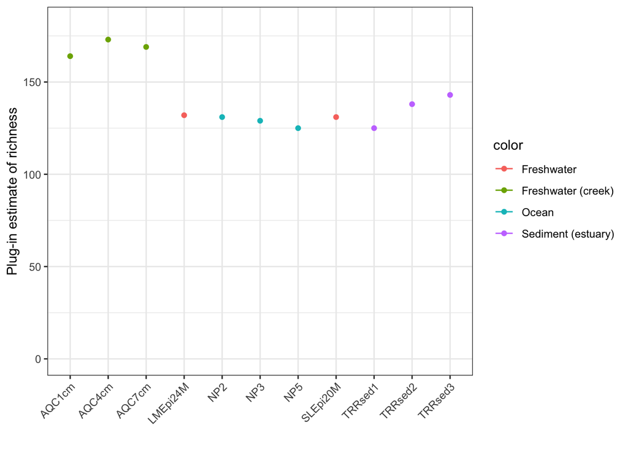

```r
observed_phyloseq <- sample_richness(water_order)
plot(observed_phyloseq, water_order, color = "SampleType")
```

Based on the plot, Freshwater (creek) appears to have the highest observed richness. However, what might be a confounding factor of observed richness?

```
## [1] "sequencing_depth!"
```

What might we expect to see if we plotted observed richness of each SampleType by their sequencing depth?

We can use ggplot and phyloseq to plot our sample types by observed richness and sequencing depth.

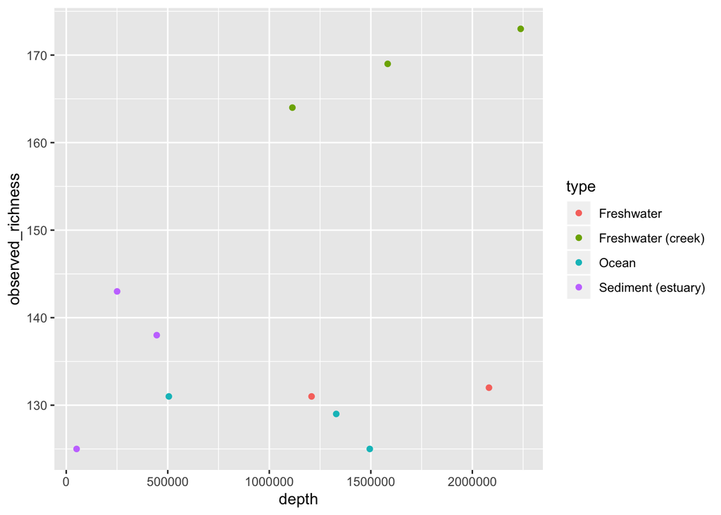

```r
data.frame("observed_richness" = (observed_phyloseq %>% summary)$estimate,
           "depth" = phyloseq::sample_sums(water_order), # Easter egg! Phyloseq's function to get depth
           "type" = water_order %>% sample_data %>% get_variable("SampleType")) %>%
  ggplot(aes(x = depth, y = observed_richness, color = type)) +
  geom_point()
```

## answer: `breakaway`

Instead of randomly subsampling our data so that our samples have some uniform lower sequencing depth (does this seem like a good idea? seems like we might be losing some valuable information by doing this) why don’t we use the information that we have to estimate the number of missing species with a species richness estimator. (Statistics is so cool)

We can do that using `breakaway()`.

```r
ba <- breakaway(water_order)
ba
```

```
## A collection of 11 alpha diversity estimates:
##
## $ LMEpi24M
## Estimate of richness from method breakaway:
##   Estimate is 154 with standard error 23.83
##   Confidence interval: (133, 897)
##   Cutoff:  12
##
## $ SLEpi20M
## Estimate of richness from method breakaway:
##   Estimate is 155 with standard error 16.43
##   Confidence interval: (132, 662)
##   Cutoff:  16
##
## $ AQC1cm
## Estimate of richness from method breakaway:
##   Estimate is 201 with standard error 50.62
##   Confidence interval: (165, 2259)
##   Cutoff:  6
##
## $ AQC4cm
## Estimate of richness from method breakaway:
##   Estimate is 184 with standard error 13.91
##   Confidence interval: (173, 486)
##   Cutoff:  4
##
## $ AQC7cm
## Estimate of richness from method breakaway:
##   Estimate is 174 with standard error 6.87
##   Confidence interval: (169, 269)
##   Cutoff:  10
##
## $ NP2
## Estimate of richness from method breakaway:
##   Estimate is 142 with standard error 5.71
##   Confidence interval: (132, 240)
##
##
## $ NP3
## Estimate of richness from method breakaway:
```

[output cut: 11 more lines]

```
## Estimate of richness from method breakaway:
##   Estimate is 140 with standard error 6.11
##   Confidence interval: (127, 259)
##
##
## $ TRRsed2
## Estimate of richness from method breakaway:
##   Estimate is 140 with standard error 139.04
##   Confidence interval: (138, 773)
##
##
## $ TRRsed3
## Estimate of richness from method breakaway:
##   Estimate is 167 with standard error 9.86
##   Confidence interval: (145, 436)
```

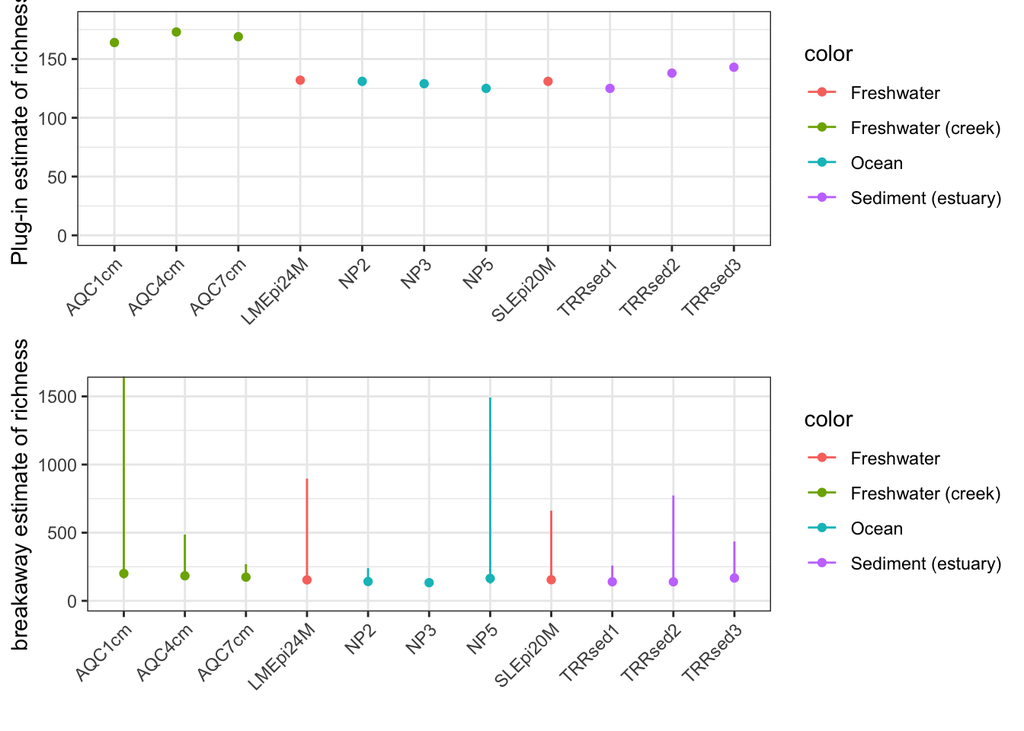

```r
plot(ba, water_order, color = "SampleType") -> p1
plot(observed_phyloseq, water_order, color = "SampleType") -> p2
library(gridExtra)
grid.arrange(p2, p1, nrow = 2)
```

Here we’re comparing our results with the previous plot we generated using `phyloseq`’s observed richness estimator. What looks different? The most obvious is that there are error bars around our estimates of observed order-level richness! Makes sense to have them, right?

**Thought exercise:** If you were to perform a hypothesis test comparing freshwater (creek) samples vs. sediment observed richnesses using the two different estimators we’ve investigated (`phyloseq` vs. `breakaway`) what might be the qualitative implications of either approach?

```r
ba$TRRsed1$model
```

```
## [1] "Kemp"
```

```r
# breakaway choose a Kemp model for TRRsed1. Cool!
```

Kemp models work by fitting a logit probabilistic model to a transformation of the data. We can also plot the transformation and the fit if you wanted to have a look. More details about this can be found in the paper: Willis & Bunge (2015), Biometrics)

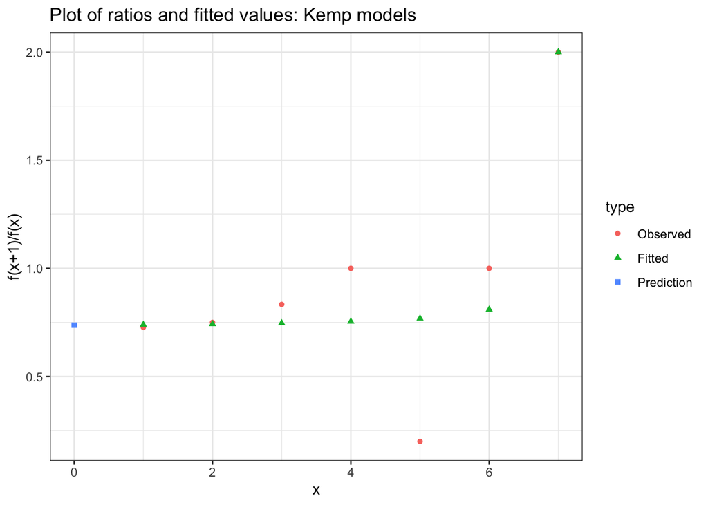

```r
tr <- water_order %>% subset_samples(X.SampleID == "TRRsed1")
# make a frequency count table of our data
fc <- tr %>% otu_table %>% make_frequency_count_table
# note: So there are 11 singletons (Orders observed once) here
# Let's fit the breakaway to this sample
ba_tr <- breakaway(fc)
ba_tr %>% plot
```

If you want to flex your ggplotting skillz you can take the estimates and turn them into a dataframe for use in ggplot!

```r
library(tibble)
summary(ba) %>%
  add_column("SampleNames" = water_order %>% otu_table %>% sample_names)
```

```
## # A tibble: 11 x 8
##    estimate  error lower upper sample_names name    model       SampleNames
##       <dbl>  <dbl> <dbl> <dbl> <chr>        <chr>   <chr>       <chr>
##  1     154.  23.8   133.  897. LMEpi24M     breaka… Negative B… LMEpi24M
##  2     155.  16.4   132.  662. SLEpi20M     breaka… Negative B… SLEpi20M
##  3     201.  50.6   165. 2259. AQC1cm       breaka… Negative B… AQC1cm
##  4     184.  13.9   173.  486. AQC4cm       breaka… Negative B… AQC4cm
##  5     174.   6.87  169.  269. AQC7cm       breaka… Negative B… AQC7cm
##  6     142.   5.71  132.  240. NP2          breaka… Kemp        NP2
##  7     133.   2.76  130.  161. NP3          breaka… Negative B… NP3
##  8     164.  31.7   126. 1492. NP5          breaka… Negative B… NP5
##  9     140.   6.11  127.  259. TRRsed1      breaka… Kemp        TRRsed1
## 10     140. 139.    138.  773. TRRsed2      breaka… Kemp        TRRsed2
## 11     167.   9.86  145.  436. TRRsed3      breaka… Kemp        TRRsed3
```

`breakaway` also implements lots of species richness estimates. For example, you could the chao-bunge estimator…

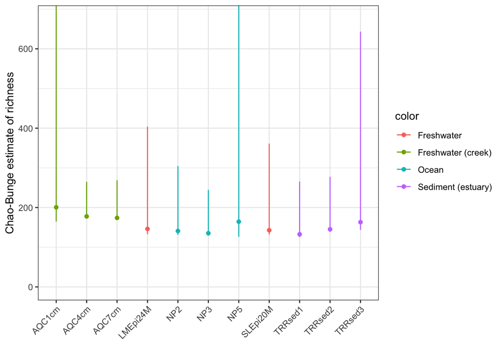

```r
water_order %>%
  chao_bunge %>%
  plot(water_order, color = "SampleType")
```

In many cases the absolute number of species isn’t as interesting as comparing ecosystems. Let’s test the hypothesis that different types of water systems have the same microbial diversity. `betta()` works like a regression model, but it accounts for the uncertainty in estimating diversity.

```r
bt <- betta(summary(ba)$estimate,
            summary(ba)$error,
            make_design_matrix(water_order, "SampleType"))
bt$table
```

```
##                               Estimates Standard Errors p-values
## (Intercept)                  154.336930        4.177664    0.000
## predictorsFreshwater (creek)  23.348476        8.797952    0.008
## predictorsOcean              -16.255139        6.428750    0.011
## predictorsSediment (estuary)  -3.760997        7.994785    0.638
```

`betta()` estimates that the mean Order-level diversity in Freshwater is 154 orders. It estimates that the diversity in creeks is significantly higher (on average 23 orders) while oceans have significantly lower diversity (on average, 16 orders). However, estuaries do not have significantly different diversity than fresh water sources. **Note** that these estimates account for different sequencing depths! `breakaway` estimates the number of missing species based on the sequence depth and number of rare taxa in the data.

The citation for `betta()` is Willis, Bunge & Whitman, 2016, JRSS-C

Please use it! It’s very important that you account for the error bars in diversity when doing hypothesis testing. `t.test`, `lm()`, `aov()`, `anova()` do not account for this – `betta()` does!

## But what if I want to estimate other diversity metrics?

Species richness counts all species equally. However, if a species is rare, you may think that it doesn’t play a role in the community. Another alpha diversity index, called the Shannon index, works similarly to species richness but it downweights the importance of rare taxa i.e. if a taxon is present but in low abundance, it doesn’t count for “1” taxon, but something less (to reflect its low abundance). Since rare taxa may be dubious, the Shannon index is very popular in microbial ecology.

For the reasons discussed in the statistics lecture, it’s important to estimate the Shannon diversity using a valid estimator of the Shannon diversity. It’s even more important to come up with the standard error, and use that standard error in testing using `betta()`.

Shockingly, until recently, there were no tools to estimate Shannon diversity in the presence of an ecological/microbial network! `DivNet` is a new tool that allows you to estimate this. It also adjusts for different sequencing depths so you don’t have to throw away any data (you don’t need to rarefy)!

Check out the preprint: Willis & Martin (2018+), bioRxiv 305045; doi: https://doi.org/10.1101/305045

DivNet is very flexible, but by default it estimates the microbial network and uses it only to adjust the standard errors on diversity estimates. DivNet can be run in parallel! This might take a minute; if it errors, try running it in series (slower but more portable): `dv_water <- divnet(water_order, ncores = 1)`

```r
dv_water_order <- divnet(water_order, ncores = 4)
```

DivNet outputs a list of the estimates shannon, simpson (alpha diversity), bray-curtis, euclidean (beta diversity)

```r
dv_water_order %>% names
```

```
##  [1] "shannon"              "simpson"              "bray-curtis"
##  [4] "euclidean"            "shannon-variance"     "simpson-variance"
##  [7] "bray-curtis-variance" "euclidean-variance"   "X"
## [10] "fitted_z"
```

You can pull them out individually:

```r
dv_water_order$shannon %>%
  summary %>%
  add_column("SampleNames" = water_order %>% otu_table %>% sample_names)
```

```
## # A tibble: 11 x 8
##    estimate    error lower upper sample_names name   model     SampleNames
##       <dbl>    <dbl> <dbl> <dbl> <chr>        <chr>  <chr>     <chr>
##  1     1.71 0.000687  1.71  1.71 LMEpi24M     DivNet Aitchison LMEpi24M
##  2     1.84 0.00177   1.84  1.84 SLEpi20M     DivNet Aitchison SLEpi20M
##  3     1.79 0.00119   1.79  1.79 AQC1cm       DivNet Aitchison AQC1cm
##  4     1.62 0.00110   1.62  1.63 AQC4cm       DivNet Aitchison AQC4cm
##  5     2.07 0.00115   2.07  2.07 AQC7cm       DivNet Aitchison AQC7cm
##  6     2.54 0.000647  2.54  2.54 NP2          DivNet Aitchison NP2
##  7     2.04 0.00202   2.04  2.04 NP3          DivNet Aitchison NP3
##  8     2.53 0.000962  2.53  2.54 NP5          DivNet Aitchison NP5
##  9     3.25 0.00589   3.24  3.26 TRRsed1      DivNet Aitchison TRRsed1
## 10     2.47 0.00170   2.47  2.48 TRRsed2      DivNet Aitchison TRRsed2
## 11     2.79 0.00109   2.79  2.80 TRRsed3      DivNet Aitchison TRRsed3
```

or plot them:

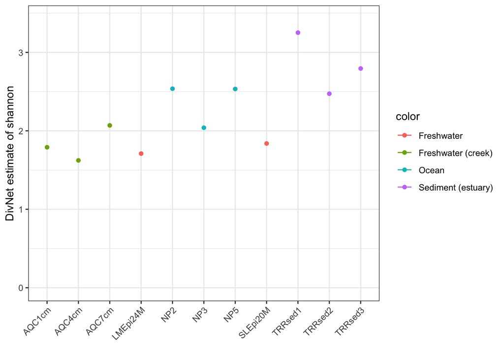

```r
plot(dv_water_order$shannon,
     water_order,
     col = "SampleType")
```

Let’s compare this to the naive approach of just “plugging in” the observed proportions to the Shannon diversity formula

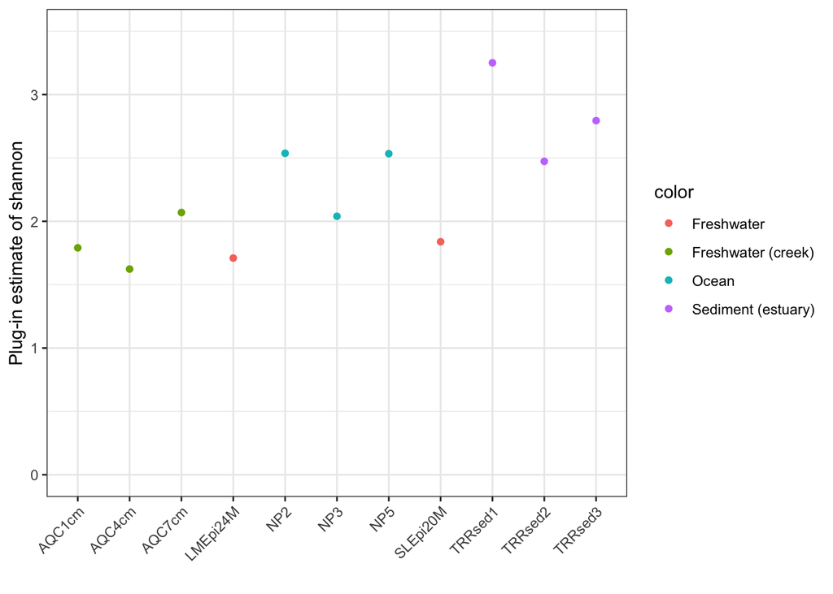

```r
plot(water_order %>% sample_shannon,
     water_order,
     col = "SampleType") + ylim(0, 3.5)
```

The error bars were the same as previously because we haven’t told DivNet anything about the experimental design. Here we observed 4 different water systems, so we will add this as a covariate

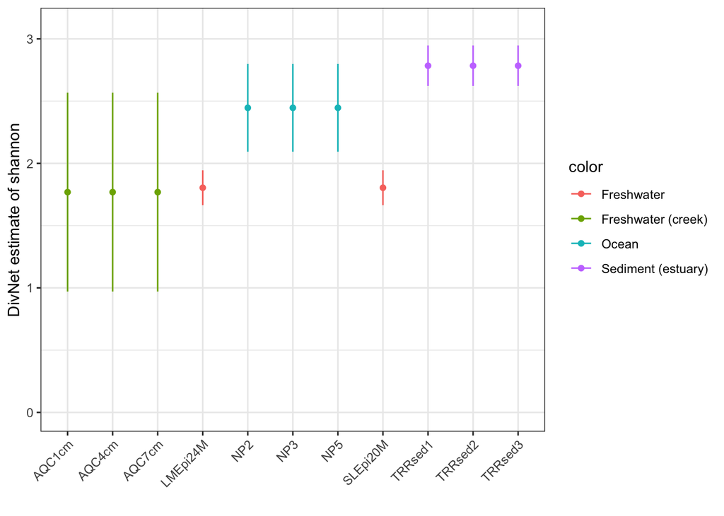

```r
dv_water_st <- divnet(water_order, X = "SampleType", ncores = 8)

plot(dv_water_st$shannon,
     water_order,
     col = "SampleType")
```

Now we see that organisms in the same group are estimated to have the same diversity. We are now estimating the diversity of this **type** of ecosystem. We’re focusing on the ecosystem, not just the samples. If we want to reproduce the results of our study, it’s better to focus on the populations that the samples come from, not the samples themselves

You can analyze sex, time, disease status in this way. It’s actually ideal for longitudinal/epigenetic studies, because you can say something about the groups, not just the people/mice in your study

Let’s look at hypothesis testing for DivNet

```r
testDiversity(dv_water_st, "shannon")
```

```
## Hypothesis testing:
##   p-value for global test: 0
```

```
##                                Estimates Standard Errors p-values
## (Intercept)                   1.80427648      0.03201089    0.000
## predictorsFreshwater (creek) -0.03537948      0.23052720    0.878
## predictorsOcean               0.64170504      0.10180285    0.000
## predictorsSediment (estuary)  0.97989907      0.04696357    0.000
```

So we have higher Shannon diversity in oceans and estuaries than in freshwater. (This is just a wrapper for `betta()`, btw)

We can also do the same thing for Simpson, of course:

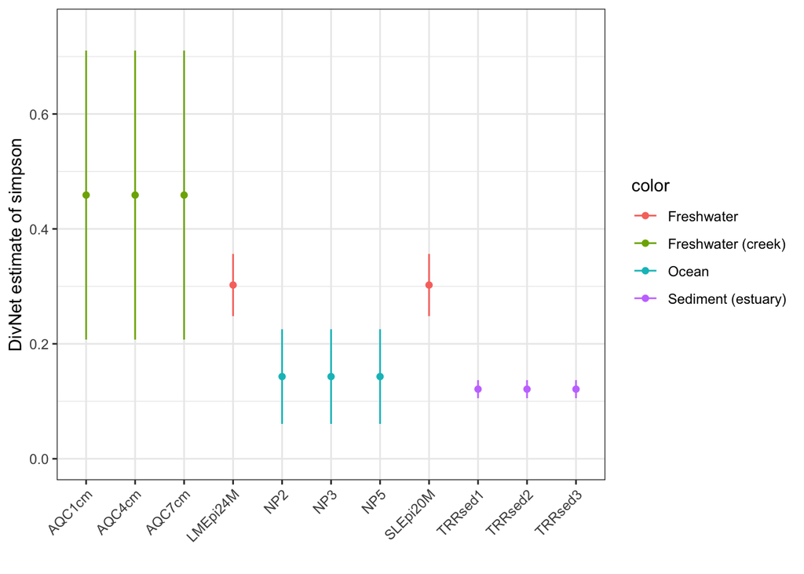

```r
plot(dv_water_st$simpson,
     water_order,
     col = "SampleType")
```

```r
testDiversity(dv_water_st, "simpson")
```

```
## Hypothesis testing:
##   p-value for global test: 0
```

```
##                               Estimates Standard Errors p-values
## (Intercept)                   0.3023418     0.004328097    0.000
## predictorsFreshwater (creek)  0.1565465     0.072595348    0.031
## predictorsOcean              -0.1593154     0.023785797    0.000
## predictorsSediment (estuary) -0.1812144     0.004531564    0.000
```

To test hypotheses about beta diversity using `DivNet`, let’s pull out our estimated distance matrix:

```r
bc <- dv_water_st$`bray-curtis`
```

You’ll notice that all samples with the same SampleType at the same estimate. DivNet uses covariate information to share strength across samples and obtain an estimate about the beta diversity of the **ecosystems** which can be defined as individual samples, groups of samples, etc…

We can consider the unique rows using:

```r
bc %>% unique
```

```
##           LMEpi24M  SLEpi20M       AQC1cm       AQC4cm       AQC7cm
## LMEpi24M 0.0000000 0.0000000 8.702335e-01 8.702335e-01 8.702335e-01
## AQC1cm   0.8702335 0.8702335 1.110223e-16 1.110223e-16 1.110223e-16
## NP2      0.8320397 0.8320397 8.058352e-01 8.058352e-01 8.058352e-01
## TRRsed1  0.9152097 0.9152097 7.947367e-01 7.947367e-01 7.947367e-01
##                NP2       NP3       NP5   TRRsed1   TRRsed2   TRRsed3
## LMEpi24M 0.8320397 0.8320397 0.8320397 0.9152097 0.9152097 0.9152097
## AQC1cm   0.8058352 0.8058352 0.8058352 0.7947367 0.7947367 0.7947367
## NP2      0.0000000 0.0000000 0.0000000 0.7898049 0.7898049 0.7898049
## TRRsed1  0.7898049 0.7898049 0.7898049 0.0000000 0.0000000 0.0000000
```

Uniquely, DivNet also has variance estimates:

```r
simplifyBeta(dv_water_st, water_order, "bray-curtis", "SampleType")
```

```
##               Covar1             Covar2     beta_est     beta_var
## 1 Freshwater (creek)         Freshwater 8.702335e-01 9.702154e-04
## 2              Ocean         Freshwater 8.320397e-01 4.063093e-04
## 3 Sediment (estuary)         Freshwater 9.152097e-01 1.042021e-04
## 4 Freshwater (creek) Freshwater (creek) 1.110223e-16 3.697785e-33
## 5              Ocean Freshwater (creek) 8.058352e-01 1.013613e-03
## 6 Sediment (estuary) Freshwater (creek) 7.947367e-01 2.822342e-03
## 7 Sediment (estuary)              Ocean 7.898049e-01 9.082948e-04
##       lower        upper
## 1 0.8079369 9.325300e-01
## 2 0.7917255 8.723539e-01
## 3 0.8947938 9.356256e-01
## 4 0.0000000 2.326411e-16
## 5 0.7421606 8.695098e-01
## 6 0.6884853 9.009882e-01
## 7 0.7295291 8.500808e-01
```

```r
simplifyBeta(dv_water_st, water_order, "euclidean", "SampleType")
```

```
##               Covar1             Covar2  beta_est     beta_var     lower
## 1 Freshwater (creek)         Freshwater 0.8490964 0.0076882559 0.6737310
## 2              Ocean         Freshwater 0.6260902 0.0001899023 0.5985292
## 3 Sediment (estuary)         Freshwater 0.6403545 0.0007074926 0.5871570
## 4              Ocean Freshwater (creek) 0.6905183 0.0116944568 0.4742364
## 5 Sediment (estuary) Freshwater (creek) 0.7419046 0.0076509897 0.5669648
## 6 Sediment (estuary)              Ocean 0.4665165 0.0014857692 0.3894251
##       upper
## 1 1.0244618
## 2 0.6536512
## 3 0.6935520
## 4 0.9068001
## 5 0.9168445
## 6 0.5436078
```

You can plot this easily:

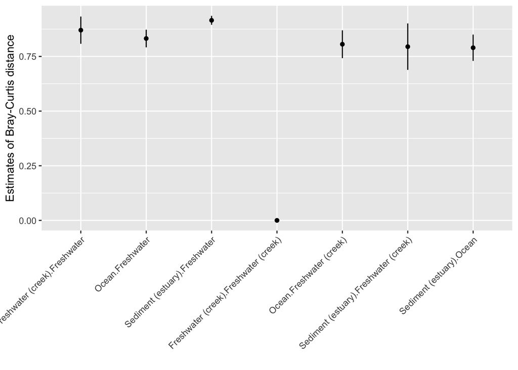

```r
simplifyBeta(dv_water_st, water_order, "bray-curtis", "SampleType") %>%
  ggplot(aes(x = interaction(Covar1, Covar2),
             y = beta_est)) +
  geom_point() +
  geom_linerange(aes(ymin = lower, ymax = upper)) +
  theme(axis.text.x = element_text(angle = 45, hjust = 1)) +
  xlab("") + ylab("Estimates of Bray-Curtis distance")
```

Finally, a teaser! Soon we will have support for phylodivnet(), to estimate UniFrac in the presence of a network. Subscribe to our github for updates. www.github.com/statdivlab/